# Tugas Individu Pertemuan 3

Regresi dengan Peubah Lag: Koyck, Distributed Lag Model (DLM), dan ARDL

M. Dava Arya Permadi — NIM 1004261009

18 September 2026

# 1 Pendahuluan

Tugas ini menerapkan tiga pendekatan regresi dengan peubah lag (**Koyck**, **Distributed Lag Model / DLM**, dan **Autoregressive Distributed Lag / ARDL**) pada data kualitas udara Kota New Delhi (`NewDelhi_Air_quality.csv`). Variabel dependen (**Y**) adalah **AQI (Air Quality Index)**, sedangkan variabel independen (**X**) yang dipilih adalah **CO (Carbon Monoxide)**.

## 1.1 Alasan pemilihan variabel X

```r
df <- read.csv("NewDelhi_Air_quality.csv")
df$datetime <- as.POSIXct(df$timestamp_local, format = "%Y-%m-%dT%H:%M:%S")
df <- df[order(df$datetime), ]
rownames(df) <- NULL
str(df[, c("AQI","CO","no2","o3","pm10","pm25","so2","datetime")])
```

```
## 'data.frame':    72 obs. of  8 variables:
##  $ AQI     : num  30.2 28.2 26.6 25 26 26 26 24 23 24 ...
##  $ CO      : num  199 198 199 202 205 ...
##  $ no2     : num  0.0469 0.0465 0.0469 0.0482 0.0489 ...
##  $ o3      : num  55.8 54.9 54.6 55.1 55.8 ...
##  $ pm10    : num  10.5 10.7 11.2 11.1 10.4 ...
##  $ pm25    : num  5.64 4.62 3.52 2.23 1.98 ...
##  $ so2     : num  0.387 0.41 0.402 0.376 0.339 ...
##  $ datetime: POSIXct, format: "2022-10-21 23:00:00" "2022-10-22 00:00:00" ...
```

```r
cor_mat <- cor(df[, c("AQI","CO","no2","o3","pm10","pm25","so2")])
round(cor_mat, 3)
```

```
##         AQI     CO    no2     o3   pm10   pm25    so2
## AQI   1.000  0.798  0.738  0.974  0.083 -0.347 -0.742
## CO    0.798  1.000  0.652  0.829 -0.096 -0.583 -0.799
## no2   0.738  0.652  1.000  0.732  0.257 -0.359 -0.586
## o3    0.974  0.829  0.732  1.000  0.034 -0.522 -0.786
## pm10  0.083 -0.096  0.257  0.034  1.000  0.268 -0.048
## pm25 -0.347 -0.583 -0.359 -0.522  0.268  1.000  0.674
## so2  -0.742 -0.799 -0.586 -0.786 -0.048  0.674  1.000
```

Korelasi terhadap AQI: **O3 (0.974)** dan **CO (0.798)** adalah yang tertinggi. O3 tidak dipilih karena korelasinya yang mendekati sempurna mengindikasikan O3 kemungkinan besar menjadi komponen dominan pembentuk nilai AQI itu sendiri pada periode data ini (hubungan hampir identik/tautologis), sehingga kurang tepat dijadikan **X** yang independen secara konseptual. **CO** dipilih sebagai variabel independen (X) karena memiliki korelasi kuat dan searah dengan AQI (0.798), namun tetap merepresentasikan polutan yang berdiri sendiri secara fisik (emisi pembakaran kendaraan/industri) — sehingga hubungan lag antara CO dan AQI lebih bermakna untuk dimodelkan.

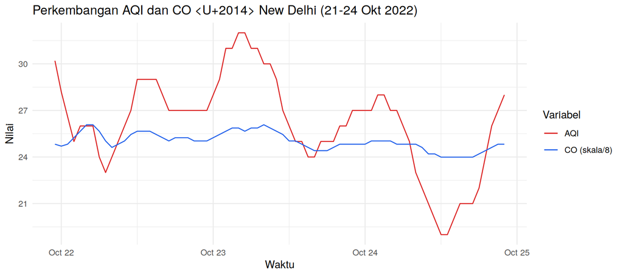

```r
ggplot(df, aes(x = datetime)) +
  geom_line(aes(y = AQI, color = "AQI")) +
  geom_line(aes(y = CO/8, color = "CO (skala/8)")) +
  scale_color_manual(values = c("AQI" = "#dc2626", "CO (skala/8)" = "#2563eb")) +
  labs(title = "Perkembangan AQI dan CO — New Delhi (21-24 Okt 2022)",
       x = "Waktu", y = "Nilai", color = "Variabel") +
  theme_minimal()
```

## 1.2 Pembagian Data (Train / Test)

Data time series berjumlah **72** observasi (data per jam). Untuk mengevaluasi kinerja peramalan, data dibagi menjadi **data latih (train)** dan **data uji (test)** — 12 observasi terakhir digunakan sebagai data uji.

```r
n <- nrow(df)
n_test <- 12
n_train <- n - n_test

train <- df[1:n_train, ]
test  <- df[(n_train + 1):n, ]

cat("Jumlah data latih :", nrow(train), "\n")
```

```
## Jumlah data latih : 60
```

```r
cat("Jumlah data uji    :", nrow(test), "\n")
```

```
## Jumlah data uji    : 12
```

```r
mape <- function(actual, pred) mean(abs((actual - pred) / actual)) * 100

lagvec <- function(x, k) {
  n <- length(x)
  if (k == 0) return(x)
  c(rep(NA, k), x[1:(n - k)])
}
```

# 2 Model 1 — Koyck

Model Koyck berangkat dari model distributed lag **tak hingga** dengan bobot koefisien yang menurun secara geometris ($\beta_i = \beta_0 \lambda^i$). Melalui transformasi Koyck, model tak hingga tersebut disederhanakan menjadi model dengan **satu lag Y** dan **X pada waktu berjalan**:

$$AQI_t = \alpha + \lambda \cdot AQI_{t-1}
+ \beta_0 \cdot CO_t + e_t$$

## 2.1 Menentukan lag optimum

Berbeda dengan DLM/ARDL, struktur Koyck **sudah baku secara matematis**: transformasi Koyck justru dibuat khusus untuk memampatkan lag X yang tak hingga menjadi **tepat satu lag** pada Y. Sehingga “lag optimum” untuk model Koyck **selalu order (1,0)** — satu lag Y, nol lag X — dan tidak memerlukan proses pencarian lag seperti DLM/ARDL. Parameter $\lambda$ (koefisien lag Y) itulah yang merepresentasikan kecepatan peluruhan pengaruh CO terhadap AQI dari waktu ke waktu.

```r
train$AQI_lag1 <- lagvec(train$AQI, 1)

koyck_model <- lm(AQI ~ AQI_lag1 + CO, data = train)
summary(koyck_model)
```

```
##
## Call:
## lm(formula = AQI ~ AQI_lag1 + CO, data = train)
##
## Residuals:
##    Min     1Q Median     3Q    Max
## -2.344 -0.696  0.237  0.453  2.093
##
## Coefficients:
##             Estimate Std. Error t value            Pr(>|t|)
## (Intercept) -14.0391     7.7471   -1.81               0.075 .
## AQI_lag1      0.8543     0.0733   11.65 <0.0000000000000002 ***
## CO            0.0885     0.0445    1.99               0.051 .
## ---
## Signif. codes:  0 '***' 0.001 '**' 0.01 '*' 0.05 '.' 0.1 ' ' 1
##
## Residual standard error: 0.94 on 56 degrees of freedom
##   (1 observation deleted due to missingness)
## Multiple R-squared:  0.85,   Adjusted R-squared:  0.845
## F-statistic:  159 on 2 and 56 DF,  p-value: <0.0000000000000002
```

```r
lambda_hat <- coef(koyck_model)["AQI_lag1"]
beta0_hat  <- coef(koyck_model)["CO"]
long_run   <- beta0_hat / (1 - lambda_hat)

cat("Lambda (kecepatan peluruhan)  :", round(lambda_hat, 4), "\n")
```

```
## Lambda (kecepatan peluruhan)  : 0.8543
```

```r
cat("Beta0  (efek jangka pendek CO):", round(beta0_hat, 4), "\n")
```

```
## Beta0  (efek jangka pendek CO): 0.0885
```

```r
cat("Efek jangka panjang CO -> AQI :", round(long_run, 4), "\n")
```

```
## Efek jangka panjang CO -> AQI : 0.6075
```

Nilai $\lambda$ = 0.8543 menunjukkan seberapa besar pengaruh AQI periode sebelumnya masih terbawa ke periode sekarang; sisanya ($\beta_0$ = 0.0885) adalah efek langsung CO pada AQI saat ini.

# 3 Model 2 — Distributed Lag Model (DLM)

Model DLM murni memasukkan **X pada berbagai lag** tanpa lag pada Y:

$$AQI_t = \alpha + \beta_0 CO_t + \beta_1
CO_{t-1} + \dots + \beta_q CO_{t-q} + e_t$$

## 3.1 Menentukan lag optimum (q)

Lag optimum dicari dengan membandingkan **AIC** dari model DLM untuk $q = 0, 1, \dots, 8$, lalu memilih $q$ dengan AIC terkecil.

```r
max_lag_dlm <- 8
aic_dlm <- numeric(max_lag_dlm + 1)

for (q in 0:max_lag_dlm) {
  dtemp <- train
  for (k in 0:q) dtemp[[paste0("CO_l", k)]] <- lagvec(dtemp$CO, k)
  form <- as.formula(paste("AQI ~", paste(paste0("CO_l", 0:q), collapse = " + ")))
  fit <- lm(form, data = dtemp)
  aic_dlm[q + 1] <- AIC(fit)
}

dlm_aic_table <- data.frame(Lag_q = 0:max_lag_dlm, AIC = round(aic_dlm, 2))
dlm_aic_table
```

| Lag_q | AIC |
| --- | --- |
| 0 | 245.23 |
| 1 | 237.01 |
| 2 | 232.65 |
| 3 | 231.17 |
| 4 | 226.46 |
| 5 | 219.03 |
| 6 | 205.90 |
| 7 | 189.23 |
| 8 | 169.14 |

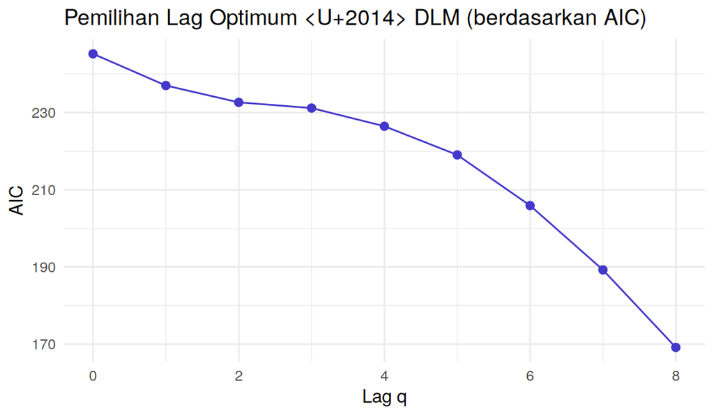

```r
ggplot(dlm_aic_table, aes(x = Lag_q, y = AIC)) +
  geom_line(color = "#4338ca") + geom_point(color = "#4338ca", size = 2) +
  labs(title = "Pemilihan Lag Optimum — DLM (berdasarkan AIC)", x = "Lag q", y = "AIC") +
  theme_minimal()
```

```r
q_opt <- dlm_aic_table$Lag_q[which.min(dlm_aic_table$AIC)]
cat("Lag optimum DLM (q) =", q_opt, "\n")
```

```
## Lag optimum DLM (q) = 8
```

```r
for (k in 0:q_opt) train[[paste0("CO_l", k)]] <- lagvec(train$CO, k)
form_dlm <- as.formula(paste("AQI ~", paste(paste0("CO_l", 0:q_opt), collapse = " + ")))
dlm_model <- lm(form_dlm, data = train)
summary(dlm_model)
```

```
##
## Call:
## lm(formula = form_dlm, data = train)
##
## Residuals:
##     Min      1Q  Median      3Q     Max
## -2.7752 -0.4517  0.0134  0.6991  2.7263
##
## Coefficients:
##             Estimate Std. Error t value   Pr(>|t|)
## (Intercept) -68.9797    12.6583   -5.45 0.00000245 ***
## CO_l0         0.7752     0.1265    6.13 0.00000026 ***
## CO_l1        -0.0155     0.2211   -0.07       0.94
## CO_l2        -0.3405     0.2203   -1.55       0.13
## CO_l3         0.1731     0.2322    0.75       0.46
## CO_l4         0.2080     0.2251    0.92       0.36
## CO_l5        -0.3573     0.2291   -1.56       0.13
## CO_l6         0.0530     0.2195    0.24       0.81
## CO_l7        -0.0421     0.2201   -0.19       0.85
## CO_l8         0.0245     0.1266    0.19       0.85
## ---
## Signif. codes:  0 '***' 0.001 '**' 0.01 '*' 0.05 '.' 0.1 ' ' 1
##
## Residual standard error: 1.11 on 42 degrees of freedom
##   (8 observations deleted due to missingness)
## Multiple R-squared:  0.835,  Adjusted R-squared:   0.8
## F-statistic: 23.7 on 9 and 42 DF,  p-value: 0.000000000000102
```

# 4 Model 3 — Autoregressive Distributed Lag (ARDL)

Model ARDL(p,q) menggabungkan lag Y (autoregresif) **dan** lag X sekaligus:

$$AQI_t = \alpha + \sum_{i=1}^{p}\phi_i
AQI_{t-i} + \sum_{j=0}^{q}\beta_j CO_{t-j} + e_t$$

## 4.1 Menentukan lag optimum (p, q)

Lag optimum $(p,q)$ dicari melalui **grid search** $p = 1,\dots,4$ dan $q = 0,\dots,4$, memilih kombinasi dengan AIC terkecil.

```r
max_p <- 4; max_q <- 4
grid <- expand.grid(p = 1:max_p, q = 0:max_q)
grid$AIC <- NA

for (i in seq_len(nrow(grid))) {
  p <- grid$p[i]; q <- grid$q[i]
  dtemp <- train
  for (k in 1:p) dtemp[[paste0("AQI_l", k)]] <- lagvec(dtemp$AQI, k)
  for (k in 0:q) dtemp[[paste0("CO_l", k)]]  <- lagvec(dtemp$CO, k)
  rhs <- paste(c(paste0("AQI_l", 1:p), paste0("CO_l", 0:q)), collapse = " + ")
  fit <- tryCatch(lm(as.formula(paste("AQI ~", rhs)), data = dtemp), error = function(e) NULL)
  if (!is.null(fit)) grid$AIC[i] <- AIC(fit)
}

grid_ordered <- grid[order(grid$AIC), ]
head(grid_ordered, 10)
```

|  | p | q | AIC |
| --- | --- | --- | --- |
| 16 | 4 | 3 | 131.68 |
| 20 | 4 | 4 | 133.68 |
| 19 | 3 | 4 | 135.91 |
| 18 | 2 | 4 | 136.05 |
| 8 | 4 | 1 | 137.13 |
| 12 | 4 | 2 | 138.10 |
| 15 | 3 | 3 | 138.52 |
| 17 | 1 | 4 | 140.06 |
| 14 | 2 | 3 | 140.93 |
| 7 | 3 | 1 | 141.01 |

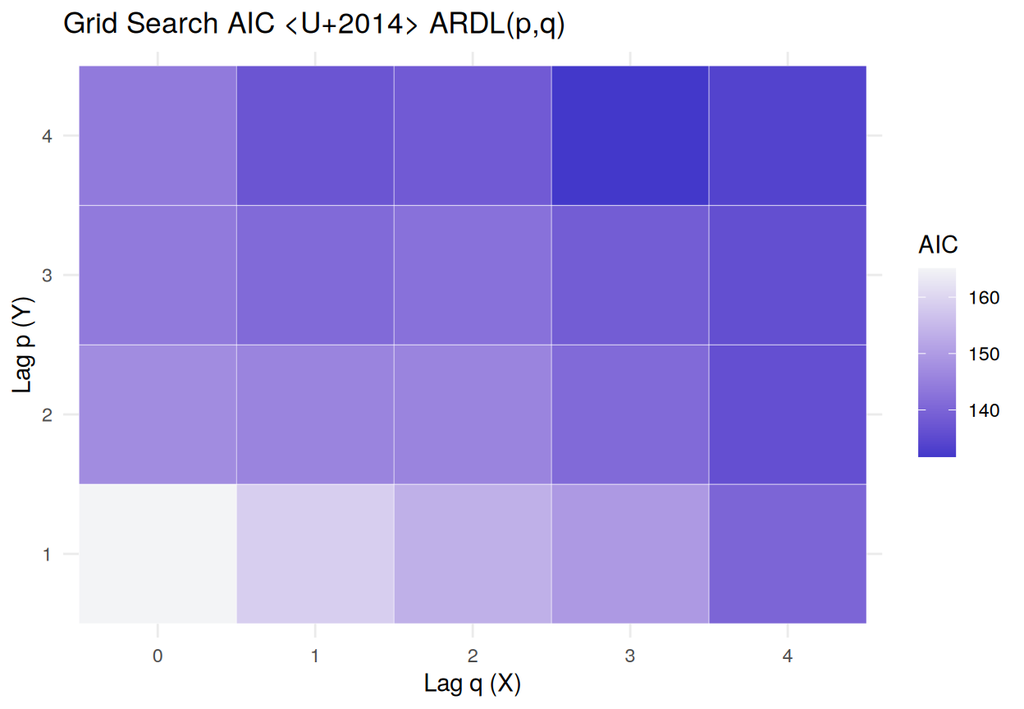

```r
ggplot(grid, aes(x = factor(q), y = factor(p), fill = AIC)) +
  geom_tile(color = "white") +
  scale_fill_gradient(low = "#4338ca", high = "#f3f4f6") +
  labs(title = "Grid Search AIC — ARDL(p,q)", x = "Lag q (X)", y = "Lag p (Y)") +
  theme_minimal()
```

```r
best <- grid_ordered[1, ]
p_opt <- best$p; q_opt_ardl <- best$q
cat("Lag optimum ARDL: p =", p_opt, ", q =", q_opt_ardl, "\n")
```

```
## Lag optimum ARDL: p = 4 , q = 3
```

```r
for (k in 1:p_opt) train[[paste0("AQI_l", k)]] <- lagvec(train$AQI, k)
for (k in 0:q_opt_ardl) train[[paste0("CO_l", k)]] <- lagvec(train$CO, k)
rhs_best <- paste(c(paste0("AQI_l", 1:p_opt), paste0("CO_l", 0:q_opt_ardl)), collapse = " + ")
ardl_model <- lm(as.formula(paste("AQI ~", rhs_best)), data = train)
summary(ardl_model)
```

```
##
## Call:
## lm(formula = as.formula(paste("AQI ~", rhs_best)), data = train)
##
## Residuals:
##     Min      1Q  Median      3Q     Max
## -1.8197 -0.3727 -0.0662  0.3638  1.6331
##
## Coefficients:
##             Estimate Std. Error t value     Pr(>|t|)
## (Intercept)  -7.0686     8.4831   -0.83       0.4089
## AQI_l1        1.0607     0.1490    7.12 0.0000000054 ***
## AQI_l2       -0.1042     0.2090   -0.50       0.6204
## AQI_l3        0.1139     0.2113    0.54       0.5925
## AQI_l4       -0.2655     0.1366   -1.94       0.0580 .
## CO_l0         0.1898     0.0825    2.30       0.0258 *
## CO_l1         0.0222     0.1310    0.17       0.8659
## CO_l2        -0.3680     0.1306   -2.82       0.0070 **
## CO_l3         0.2172     0.0787    2.76       0.0082 **
## ---
## Signif. codes:  0 '***' 0.001 '**' 0.01 '*' 0.05 '.' 0.1 ' ' 1
##
## Residual standard error: 0.716 on 47 degrees of freedom
##   (4 observations deleted due to missingness)
## Multiple R-squared:  0.926,  Adjusted R-squared:  0.913
## F-statistic: 73.3 on 8 and 47 DF,  p-value: <0.0000000000000002
```

Kombinasi lag optimum ARDL adalah **p = 4** (lag AQI) dan **q = 3** (lag CO), berdasarkan AIC terkecil = 131.68.

# 5 Uji Asumsi Model

Tiga asumsi utama diuji untuk residual masing-masing model: **normalitas** (Shapiro-Wilk), **autokorelasi** (Breusch-Godfrey), dan **heteroskedastisitas** (Breusch-Pagan).

```r
uji_asumsi <- function(model, nama) {
  sw  <- shapiro.test(residuals(model))
  bg  <- tryCatch(bgtest(model), error = function(e) list(p.value = NA))
  bp  <- tryCatch(bptest(model), error = function(e) list(p.value = NA))
  data.frame(
    Model = nama,
    Shapiro_p = round(sw$p.value, 4),
    Normalitas = ifelse(sw$p.value > 0.05, "Normal", "Tidak Normal"),
    BG_p = round(bg$p.value, 4),
    Autokorelasi = ifelse(is.na(bg$p.value), NA, ifelse(bg$p.value > 0.05, "Tidak Ada", "Ada")),
    BP_p = round(bp$p.value, 4),
    Heteroskedastisitas = ifelse(is.na(bp$p.value), NA, ifelse(bp$p.value > 0.05, "Homoskedastik", "Heteroskedastik"))
  )
}

tabel_asumsi <- rbind(
  uji_asumsi(koyck_model, "Koyck"),
  uji_asumsi(dlm_model, "DLM"),
  uji_asumsi(ardl_model, "ARDL")
)
tabel_asumsi
```

|  | Model | Shapiro_p | Normalitas | BG_p | Autokorelasi | BP_p | Heteroskedastisitas |
| --- | --- | --- | --- | --- | --- | --- | --- |
| BP | Koyck | 0.1895 | Normal | 0.0000 | Ada | 0.1819 | Homoskedastik |
| BP1 | DLM | 0.0503 | Normal | 0.0001 | Ada | 0.1110 | Homoskedastik |
| BP2 | ARDL | 0.3514 | Normal | 0.9703 | Tidak Ada | 0.9141 | Homoskedastik |

**Interpretasi ringkas:** nilai p-value > 0.05 pada uji Shapiro-Wilk menunjukkan residual berdistribusi normal; p-value > 0.05 pada uji Breusch-Godfrey menunjukkan tidak ada autokorelasi; dan p-value > 0.05 pada uji Breusch-Pagan menunjukkan varian residual homoskedastik (konstan). Jika salah satu asumsi dilanggar, model tetap dapat digunakan untuk peramalan namun interpretasi inferensia (uji-t, uji-F) perlu dilakukan dengan hati-hati (misalnya menggunakan galat baku robust HAC).

# 6 Evaluasi & Perbandingan Kinerja Peramalan

Peramalan dilakukan secara **rekursif (dynamic forecast)** pada data uji (12 jam terakhir): nilai AQI hasil ramalan periode sebelumnya digunakan sebagai input lag Y untuk periode berikutnya (bukan nilai aktual), agar mencerminkan situasi peramalan riil ke depan.

```r
full <- df
full$AQI_l1 <- lagvec(full$AQI, 1)
for (k in 1:max(p_opt, 1)) full[[paste0("AQI_l", k)]] <- lagvec(full$AQI, k)
for (k in 0:max(q_opt, q_opt_ardl)) full[[paste0("CO_l", k)]] <- lagvec(full$CO, k)

idx_test <- (n_train + 1):n
actual_test <- df$AQI[idx_test]
```

```r
y_hist <- df$AQI[1:n_train]
pred_koyck <- numeric(n_test)
y_prev <- y_hist[n_train]
for (i in seq_len(n_test)) {
  x_now <- df$CO[n_train + i]
  y_prev <- as.numeric(coef(koyck_model)["(Intercept)"] +
                        coef(koyck_model)["AQI_lag1"] * y_prev +
                        coef(koyck_model)["CO"] * x_now)
  pred_koyck[i] <- y_prev
}
```

```r
co_hist <- df$CO
pred_dlm <- numeric(n_test)
for (i in seq_len(n_test)) {
  t_idx <- n_train + i
  xrow <- sapply(0:q_opt, function(k) co_hist[t_idx - k])
  names(xrow) <- paste0("CO_l", 0:q_opt)
  pred_dlm[i] <- as.numeric(coef(dlm_model)["(Intercept)"] + sum(coef(dlm_model)[paste0("CO_l", 0:q_opt)] * xrow))
}
```

```r
y_buffer <- df$AQI[1:n_train]
pred_ardl <- numeric(n_test)
for (i in seq_len(n_test)) {
  t_idx <- n_train + i
  y_lags <- sapply(1:p_opt, function(k) if (i - k > 0) pred_ardl[i - k] else y_buffer[n_train + i - k])
  x_lags <- sapply(0:q_opt_ardl, function(k) co_hist[t_idx - k])
  names(y_lags) <- paste0("AQI_l", 1:p_opt)
  names(x_lags) <- paste0("CO_l", 0:q_opt_ardl)
  pred_ardl[i] <- as.numeric(coef(ardl_model)["(Intercept)"] +
                              sum(coef(ardl_model)[paste0("AQI_l", 1:p_opt)] * y_lags) +
                              sum(coef(ardl_model)[paste0("CO_l", 0:q_opt_ardl)] * x_lags))
}
```

```r
mape_koyck <- mape(actual_test, pred_koyck)
mape_dlm   <- mape(actual_test, pred_dlm)
mape_ardl  <- mape(actual_test, pred_ardl)

hasil_eval <- data.frame(
  Model = c("Koyck", "DLM", "ARDL"),
  Lag_Optimum = c("p=1, q=0 (baku)", paste0("q=", q_opt), paste0("p=", p_opt, ", q=", q_opt_ardl)),
  Deviance_Train = round(c(deviance(koyck_model), deviance(dlm_model), deviance(ardl_model)), 3),
  AIC_Train = round(c(AIC(koyck_model), AIC(dlm_model), AIC(ardl_model)), 2),
  MAPE_Test = round(c(mape_koyck, mape_dlm, mape_ardl), 3)
)
hasil_eval
```

| Model | Lag_Optimum | Deviance_Train | AIC_Train | MAPE_Test |
| --- | --- | --- | --- | --- |
| Koyck | p=1, q=0 (baku) | 49.518 | 165.10 | 9.359 |
| DLM | q=8 | 51.570 | 169.14 | 8.015 |
| ARDL | p=4, q=3 | 24.090 | 131.68 | 8.671 |

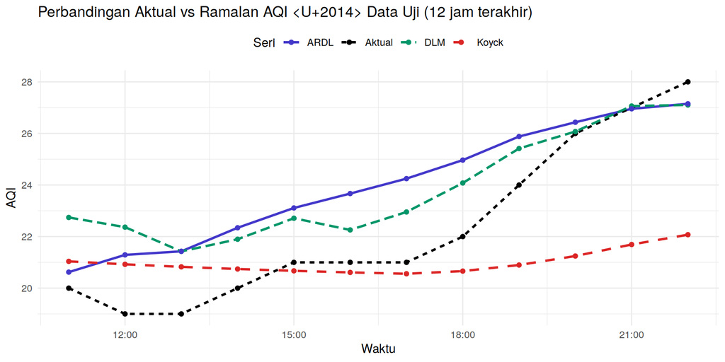

```r
plot_df <- data.frame(
  datetime = rep(df$datetime[idx_test], 4),
  AQI = c(actual_test, pred_koyck, pred_dlm, pred_ardl),
  Seri = rep(c("Aktual", "Koyck", "DLM", "ARDL"), each = n_test)
)

ggplot(plot_df, aes(x = datetime, y = AQI, color = Seri, linetype = Seri)) +
  geom_line(linewidth = 1) + geom_point(size = 1.6) +
  scale_color_manual(values = c("Aktual" = "black", "Koyck" = "#dc2626", "DLM" = "#059669", "ARDL" = "#4338ca")) +
  labs(title = "Perbandingan Aktual vs Ramalan AQI — Data Uji (12 jam terakhir)",
       x = "Waktu", y = "AQI") +
  theme_minimal() +
  theme(legend.position = "top")
```

Berdasarkan **MAPE** pada data uji, model dengan nilai MAPE terkecil dianggap memiliki kinerja peramalan terbaik. Berdasarkan **deviance/AIC** pada data latih, model dengan nilai terkecil dianggap paling baik kesesuaiannya (goodness of fit) terhadap data historis.

```r
best_model_name <- hasil_eval$Model[which.min(hasil_eval$MAPE_Test)]
cat("Model dengan MAPE (data uji) terkecil:", best_model_name, "\n")
```

```
## Model dengan MAPE (data uji) terkecil: DLM
```

# 7 Kesimpulan

1. Variabel independen (X) yang digunakan adalah **CO**, dipilih karena memiliki korelasi kuat (0.798) dan bermakna secara fisik terhadap AQI, tanpa risiko tautologi seperti O3.
2. Lag optimum masing-masing metode:
   - **Koyck**: order tetap (1,0) — bawaan dari transformasi geometrik.
   - **DLM**: q = 8 (dipilih berdasarkan AIC minimum).
   - **ARDL**: p = 4, q = 3 (dipilih berdasarkan AIC minimum hasil grid search).
3. Uji asumsi menunjukkan kondisi normalitas, autokorelasi, dan heteroskedastisitas sebagaimana dirangkum pada tabel di atas — perlu diperhatikan pada tahap interpretasi koefisien.
4. Berdasarkan metrik **MAPE** pada data uji, model **DLM** memberikan hasil peramalan yang paling akurat pada horizon 12 jam ke depan untuk kasus data ini.

*Catatan: karena rentang data yang tersedia relatif pendek (72 observasi / ± 3 hari), hasil pemilihan lag dan performa model dapat berubah apabila diterapkan pada rentang data yang lebih panjang.*